# R Notebook

# AUFGABE 14: Kruskal-Wallis-Test (Falls die Vorauszetzungen für ANOVA ohne Messwiederholung entsprechen nicht!)

## Beschreibung:

Welcher Haushalt verbraucht mehr Wasser? Ist es das WG-Zimmer, das Haus, die Wohung oder das Loch? Der Wasserverbrauch wird pro Person kalkuliert. Und wie stark ist der Effekt?

Daten Variable1: Lebensraum Varibale2: Wasseverbrauch

```r
library(readxl)
uebung14 <- read_excel("uebung14.xlsx")
uebung14$Lebensraum <- uebung14$Lebenraum
uebung14
```

| ID | Lebenraum | Wasserverbrauch | Lebensraum |
| --- | --- | --- | --- |
| 1 | Zimmer | 15 | Zimmer |
| 2 | Zimmer | 20 | Zimmer |
| 3 | Zimmer | 14 | Zimmer |
| 4 | Zimmer | 21 | Zimmer |
| 5 | Zimmer | 13 | Zimmer |
| 6 | Zimmer | 15 | Zimmer |
| 7 | Zimmer | 21 | Zimmer |
| 8 | Zimmer | 25 | Zimmer |
| 9 | Zimmer | 21 | Zimmer |
| 10 | Zimmer | 20 | Zimmer |

[output cut: 30 more lines]

# 1) Hypothese

H1: Es gibt einen Unterschied in der zentralen Tendenz zwischen der Lebensraum und dem Wasserverbrauch. H0: Es gibt keinen Unterschied in der zentralen Tendenz zwischen der Lebensraum und dem Wasserverbrauch.

# 2) Voraussetzungen für den Kruskal-Wallis-Test

Die abhängige Variable ist mindestens ordinalskaliert. Ja, die Var. “Wasserverbrauch” ist metrisch.

Es liegt eine unabhängige Variable vor, mittels der die zu vergleichenden Gruppen gebildet werden. Es muss kategorical oder ordinal sein. Faktor “Lebensraum”-> Faktorstufen/Ausprägung (Haus, Zimmer, Wohnung, Loch)

# 3) Grundlegende Konzepte

Der Kruskal-Wallis-Test wird “H-Test” genannt. Er untersucht für unabhängige Stichproben, ob sich die zentralen Tendenzen mehrerer unabhängiger Stichproben unterscheiden. Der Kruskal-Wallis-Test wird verwendet, wenn die Voraussetzungen für eine ANOVA nicht erfüllt sind.

Der H-Test ist das nichtparametrische Äquivalent der einfaktoriellen Varianzanalyse ohne Messwiederholung und wird angewendet, wenn die Voraussetzungen für ein parametrisches Verfahren nicht erfüllt sind.

Bei diesen Ausprägungen eignet sich der H-Test:

- kleine Stichproben
- Ausreisser
- ordinalskalierte Daten
- keine Normalverteilung

Die Fragestellung des Kruskal-Wallis-Tests wird oft so verkürzt: “Unterscheiden sich die zentralen Tendenzen mehrerer unabhängiger Stichproben?”

# 4) Deskriptive Statistiken + Boxplots

### Deskriptive Statistiken

```r
library(dplyr)

uebung14 %>%

group_by(Lebensraum) %>%

summarize(Anzahl = n(), Mittelwert = mean(Wasserverbrauch), Median = median(Wasserverbrauch), Standardabweichung = sd(Wasserverbrauch)) %>%
mutate_if(is.numeric, round, 2)
```

| Lebensraum | Anzahl | Mittelwert | Median | Standardabweichung |
| --- | --- | --- | --- | --- |
| Haus | 7 | 87.71 | 86.0 | 13.39 |
| Loch | 11 | 7.36 | 7.0 | 4.63 |
| Wohnung | 10 | 54.00 | 56.5 | 9.17 |
| Zimmer | 12 | 17.67 | 18.5 | 4.33 |

```r
# library(dplyr)-> Deskriptive Statistiken
uebung14 %>%
group_by(Lebensraum) %>% # Spilten auf die Wohnraumarten
  summarize(Anzahl = n(),  Median = median(Wasserverbrauch)) %>% #Anzahl und der Median
  mutate_if(is.numeric, round, 2) # die Daten werden gerundet
```

| Lebensraum | Anzahl | Median |
| --- | --- | --- |
| Haus | 7 | 86.0 |
| Loch | 11 | 7.0 |
| Wohnung | 10 | 56.5 |
| Zimmer | 12 | 18.5 |

Der Wasserverbrauch in den Wohntypen unterscheidet sich. Angefangen bei dem geringsten Verbrauch mit 7 l pro Tag pro Person (Loch: n=11), gefolgt vom Lebensraum “Zimmer” mit 18.5 l pro Tag pro Person (n=12). Die Wohnform “Wohnung” verbraucht 56.5 l pro Tag pro Person (n=10). Den höchsten Wasserverbrauch hat die Wohnform “Haus” mit 86.0 l pro Tag pro Person (n=7).

# Boxplots

```r
# Die Reihenfolge kann geändert werden,  damit der Boxplot geordnet aussieht.
uebung14$Lebensraum <- factor(uebung14$Lebensraum, levels=c("Haus", "Wohnung", "Zimmer", "Loch"))
```

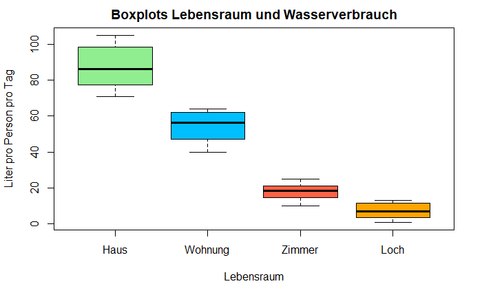

```r
boxplot(uebung14$Wasserverbrauch ~ uebung14$Lebensraum, main = "Boxplots Lebensraum und Wasserverbrauch", ylab = "Liter pro Person pro Tag", xlab= "Lebensraum" , col = c("lightgreen", "deepskyblue","tomato","orange"))
```

Die Mediane unterscheiden sich. Es gibt keine Ausreißer. Es gibt eine Überschneidung zwischen “Loch” und “Zimmer”.

### Alternative:

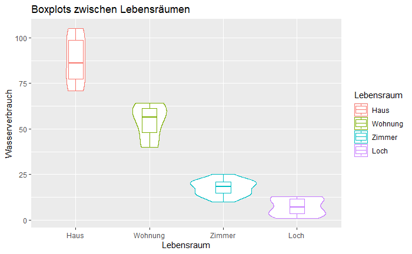

```r
library(ggplot2)

ggplot(uebung14, aes(x=Lebensraum, y=Wasserverbrauch, color=Lebensraum)) +
geom_violin() +
geom_boxplot(width=0.2) +
labs(x= "Lebensraum",y = "Wasserverbrauch", title="Boxplots zwischen Lebensräumen")
```

# 5) Ergebnisse der Kruskal-Wallis-Test

```r
test <- kruskal.test(Wasserverbrauch ~ Lebensraum, data=uebung14)
test
```

```
    Kruskal-Wallis rank sum test

data:  Wasserverbrauch by Lebensraum
Kruskal-Wallis chi-squared = 35.527, df = 3, p-value = 9.429e-08
```

Die Tabelle zeigt Unterschiede. Für das Beispiel wird eine Signifikanz von <.000 ausgegeben. Also kann davon ausgegangen werden, dass es Unterschiede bezüglich der zentralen Tendenzen der Gruppen gibt (Chi-Quadrat(3) = 35.527,p < .000).

Allerdings lässt sich aufgrund dieses Tests nicht bestimmen, welche der vier Gruppen sich signifikant voneinander unterscheiden. Es ist denkbar, dass sich lediglich ein Paar signifikant unterscheidet und zwischen den übrigen keine signifikanten Unterschiede vorliegen. Daher wird ein Post-hoc-Test durchgeführt.

# 6) Post-hoc-Tests

```r
PostHoc <- aov(Wasserverbrauch ~ Lebensraum, data=uebung14)
TukeyHSD(PostHoc)
```

```
  Tukey multiple comparisons of means
    95% family-wise confidence level

Fit: aov(formula = Wasserverbrauch ~ Lebensraum, data = uebung14)

$Lebensraum
                    diff       lwr        upr     p adj
Wohnung-Haus   -33.71429 -44.21317 -23.215402 0.0000000
Zimmer-Haus    -70.04762 -80.17984 -59.915393 0.0000000
Loch-Haus      -80.35065 -90.65116 -70.050143 0.0000000
Zimmer-Wohnung -36.33333 -45.45530 -27.211368 0.0000000
Loch-Wohnung   -46.63636 -55.94489 -37.327836 0.0000000
Loch-Zimmer    -10.30303 -19.19596  -1.410105 0.0178246
```

Der Post-Hoc-Test ergibt, dass sich alle vergleichenden Gruppen signifikant unterscheiden (p < 0.05).

Es gibt einem signifikanten Unterschied zwischen den sechs getesteten Gruppen, das heisst, dass jeder Lebensraum einen deutlichen Unterschied in ihrem Wasserverbrauch aufweisen.

# 7) Berechnung der Effektstärke

Variante 1:

$$r=\left\| \frac{z}{\sqrt{n}} \right\|$$

```r
Zstat<-qnorm(test$p.value/2) # Es wird durch zwei geteilt, weil die Hypothese ungerichtet ist.
sprintf("Z-Wert für den H-Test : %.2f", Zstat)
```

```
[1] "Z-Wert für den H-Test : -5.34"
```

```r
daten <- nrow(uebung14)
sprintf("Anzahl der Daten: %.f", daten)
```

```
[1] "Anzahl der Daten: 40"
```

```r
eff <- abs(Zstat/sqrt(daten))
sprintf("Effektstärke: %.2f", eff)
```

```
[1] "Effektstärke: 0.84"
```

Zur Beurteilung der Grösse des Effektes dient die Einteilung von Cohen (1992):

$$\begin{align}
\text{Schwacher Effekt: } 0.10 &< ||r|| < 0.30 \\
\text{Schwacher bis mittlerer Effekt: } 0.30 &= ||r|| \\
\text{Mittlerer Effekt: } 0.30 &< ||r|| < 0.50 \\
\text{Mittlerer bis starker Effekt: }0.50 &= ||r|| \\
\text{Starker Effekt: } 0.50 &< ||r||
\end{align}$$

Damit entspricht eine Effektstärke von .84 einem starken Effekt.

### Variante 2:

$$w = \left|\sqrt\frac{\mathcal{X}^2}{n}\right|$$

```r
anzahl <- nrow(uebung14)
chi <- test$statistic

w<- sqrt(chi /anzahl)
sprintf("Effektstärke mit w: %f",w)
```

```
[1] "Effektstärke mit w: 0.942424"
```

$$\begin{align}
\text{Schwacher Effekt: } 0.10 &< w \le 0.30 \\
\text{Mittlerer Effekt: } 0.30 &< w \le 0.50 \\
\text{Starker Effekt: } 0.50 &< w
\end{align}$$

Damit entspricht eine Effektstärke von 0.9424 einem starken Effekt.

# 8) Eine Aussage

Der Kruskal-Wallis-Test bestätigt, dass der Wasswerverbrauch sich durch die Lebensraum unterscheidet (Chi-Quadrat(3) = 35.527,p < .000).

Der anschliessend durchgeführte Post-hoc-Test (Tukey) zeigt, dass alle Gruppen sich unterscheiden (p < 0.05). Angefangen bei dem geringsten Verbrauch mit 7 l pro Tag pro Person (Loch: n=11), gefolgt vom Lebensraum “Zimmer” mit 18.5 l pro Tag pro Person (n=12). Die Wohnform “Wohnung” verbraucht 56.5 l pro Tag pro Person (n=10). Den höchsten Wasserverbrauch hat die Wohnform “Haus” mit 86.0 l pro Tag pro Person (n=7).

Die Effektstärke nach Cohen (1992) (r = .84) zeigt ein starken Effekt, sodass tatsächlich der Lebensraunm einen grossen Effekt auf den Wasserverbrauch hat. H0 wird ablehnen, H1 angenommen.